# Data Wrangling and Graphing COVID-19 Reporting Data (Part 2)

## Challenge Exercises

### Challenge Exercise 1

Revise the above example for joining tables using 6/13/2020 and 9/13/2020. Plot the data as a bar plot. Make sure your graph looks nice in the report by adjusting the height of the graph in the R code chunk header.

```r
library(tidyverse)

Confirmed_6_13 <-   read_csv(url("https://raw.githubusercontent.com/CSSEGISandData/COVID-19/master/csse_covid_19_data/csse_covid_19_daily_reports/06-13-2020.csv")) %>%
  filter (Country_Region == "US") %>%
  group_by(Province_State, Country_Region) %>%
  summarise(Confirmed = sum(Confirmed))

str(Confirmed_6_13)
```

```r
library(tidyverse)

Confirmed_9_13 <-   read_csv(url("https://raw.githubusercontent.com/CSSEGISandData/COVID-19/master/csse_covid_19_data/csse_covid_19_daily_reports/09-13-2020.csv")) %>%
  filter (Country_Region == "US") %>%
  group_by(Province_State, Country_Region) %>%
  summarise(Confirmed = sum(Confirmed))

str(Confirmed_9_13)
```

**Note: Both dataframes have 58 U.S. States and Territories, so no need to make any changes.**

```r
library(tidyverse)

Confirmed_6_13_9_13_joined <- full_join(Confirmed_6_13,
      Confirmed_9_13, by = c("Province_State")) %>%
  rename(Confirmed_6_13 = Confirmed.x, Confirmed_9_13 = Confirmed.y) %>%
  select(-Country_Region.x, -Country_Region.y) %>%
  gather(key="Date", value="Cases", 2:length(.))

head(Confirmed_6_13_9_13_joined)
```

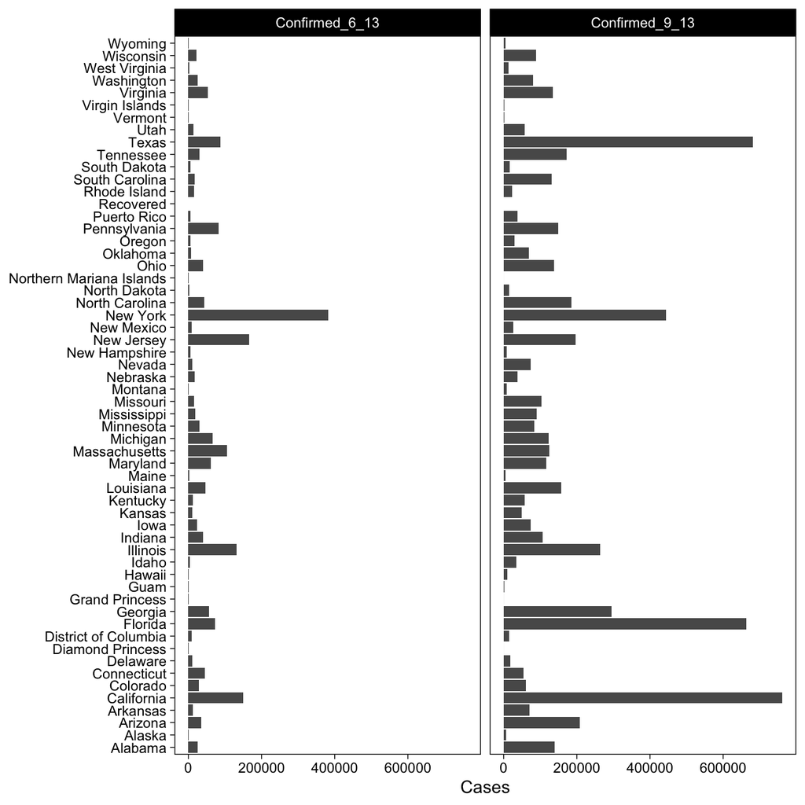

```r
options(scipen=999)

library(ggplot2)

ggplot(Confirmed_6_13_9_13_joined, aes(x=Cases, y=Province_State)) +
  geom_bar(stat="identity") +
  facet_wrap(~Date, ncol=2) +
  theme_linedraw() +
  theme(panel.grid=element_blank(),
        axis.title.y=element_blank())
```

### Challenge Exercise 2

Add more informative x and y labels and a title to the above graph in Ex1.

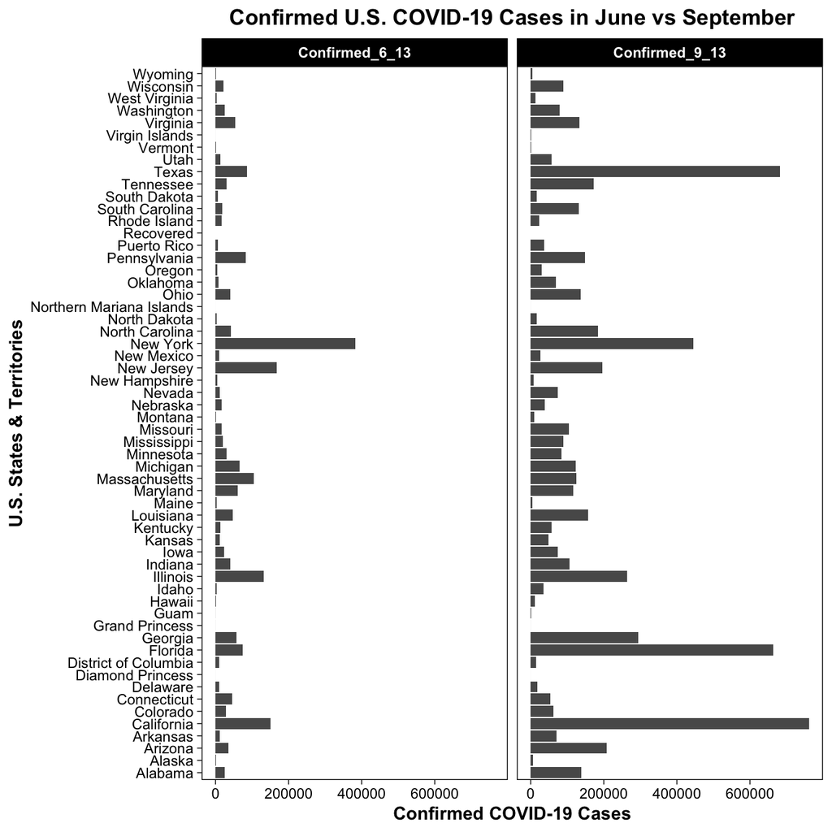

```r
options(scipen=999)

library(ggplot2)

ggplot(Confirmed_6_13_9_13_joined, aes(x=Cases, y=Province_State)) +
  geom_bar(stat="identity") +
  labs(x="Confirmed COVID-19 Cases", y="U.S. States & Territories", title="Confirmed U.S. COVID-19 Cases in June vs September") +
  facet_wrap(~Date, ncol=2) +
  theme_linedraw() +
  theme(panel.grid=element_blank(),
        strip.text=element_text(face="bold"),
        axis.title.x=element_text(face="bold"),
        axis.title.y=element_text(face="bold"),
        plot.title=element_text(face="bold", hjust=0.5))
```

### Challenge Exercise 3

Using the time series data. Make a plot of the total number of confirmed deaths per day worldwide

```r
library(tidyverse)

time_series_deaths <- read_csv(url("https://raw.githubusercontent.com/CSSEGISandData/COVID-19/master/csse_covid_19_data/csse_covid_19_time_series/time_series_covid19_deaths_global.csv")) %>%
  rename(Province_State = "Province/State", Country_Region = "Country/Region") %>%
  gather(key="Date", value="Deaths", 5:length(.)) %>%
  mutate(Date = lubridate::mdy(Date))

head(time_series_deaths)
```

```r
time_series_deaths_per_date <- time_series_deaths %>%
  group_by(Date) %>%
  summarize(Deaths = sum(Deaths)) %>%
  mutate(Deaths_per_day = Deaths - lag(Deaths))

head(time_series_deaths_per_date)
```

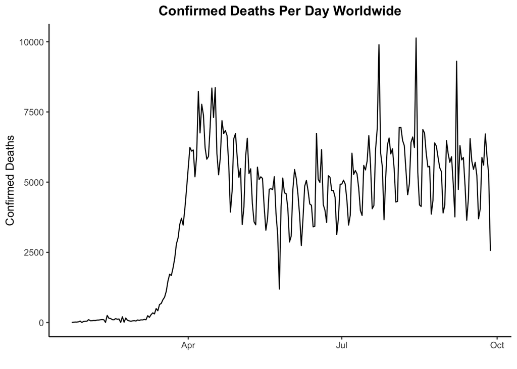

```r
library(ggplot2)

ggplot(time_series_deaths_per_date, aes(x=Date, y=Deaths_per_day)) +
  geom_line() +
  labs(x="", y="Confirmed Deaths", title="Confirmed Deaths Per Day Worldwide") +
  theme_classic() +
  theme(plot.title = element_text(hjust=0.5, face="bold"))
```

### Challenge Exercise 4

Use Mutate to make a new column with deaths/confirmed cases (Hint: this might be best done after joining the tables, but before pivoting longer).

```r
library(tidyverse)

time_series_confirmed <- read_csv(url("https://raw.githubusercontent.com/CSSEGISandData/COVID-19/master/csse_covid_19_data/csse_covid_19_time_series/time_series_covid19_confirmed_global.csv")) %>%
  rename(Province_State = "Province/State", Country_Region = "Country/Region") %>%
  mutate(report_type = "confirmed_cases") %>%
  select(report_type, everything())

head(time_series_confirmed)
```

```r
library(tidyverse)

time_series_deaths <- read_csv(url("https://raw.githubusercontent.com/CSSEGISandData/COVID-19/master/csse_covid_19_data/csse_covid_19_time_series/time_series_covid19_deaths_global.csv")) %>%
  rename(Province_State = "Province/State", Country_Region = "Country/Region") %>%
  mutate(report_type = "confirmed_deaths") %>%
  select(report_type, everything())

head(time_series_deaths)
```

```r
library(tidyverse)

time_series_joined <- bind_rows(time_series_confirmed, time_series_deaths) %>%
  gather(key="date", value="count", 6:length(.)) %>%
  mutate(date=lubridate::mdy(date)) %>%
  spread(key="report_type", value="count") %>%
  mutate(confirmed_cases=replace_na(confirmed_cases, 0),
         confirmed_deaths=replace_na(confirmed_deaths, 0))

head(time_series_joined)
tail(time_series_joined)
```

```r
library(tidyverse)

time_series_sum <- time_series_joined %>%
  group_by(date) %>%
  summarize(cases = sum(confirmed_cases),
            deaths = sum(confirmed_deaths)) %>%
  mutate(deaths_cases = deaths/cases)

head(time_series_sum)
```

```
## # A tibble: 6 x 4
##   date       cases deaths deaths_cases
##   <date>     <dbl>  <dbl>        <dbl>
## 1 2020-01-22   555     17       0.0306
## 2 2020-01-23   654     18       0.0275
## 3 2020-01-24   941     26       0.0276
## 4 2020-01-25  1434     42       0.0293
## 5 2020-01-26  2118     56       0.0264
## 6 2020-01-27  2927     82       0.0280
```

### Challenge Exercise 5

Plot US deaths/confirmed cases per day.

```r
library(tidyverse)

time_series_sum <- time_series_joined %>%
  filter(Country_Region=="US") %>%                      #| Filter only US Data
  group_by(date) %>%
  summarize(cases = sum(confirmed_cases),
            deaths = sum(confirmed_deaths)) %>%
  mutate(deaths_cases = deaths/cases)
```

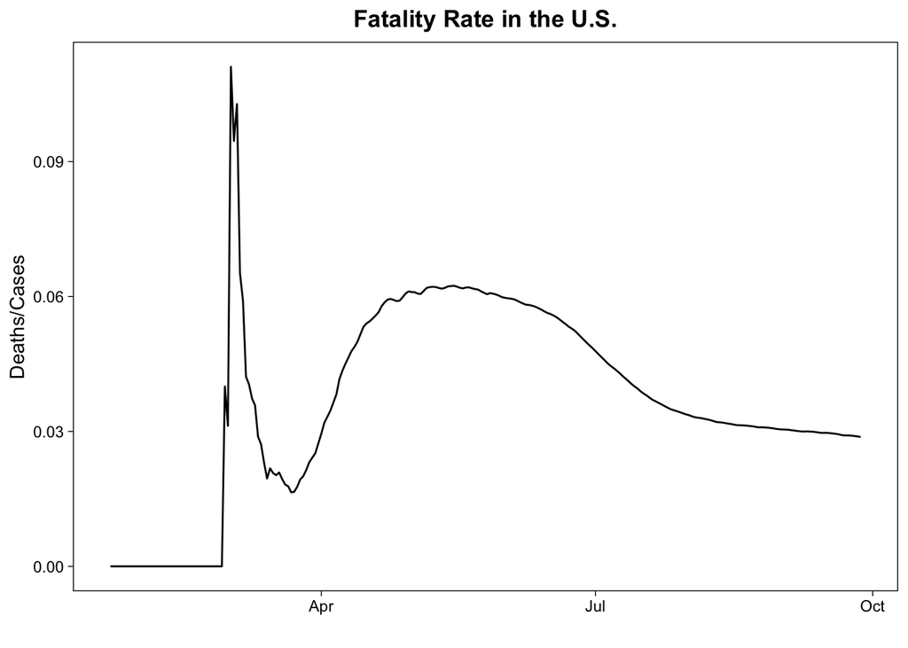

```r
library(ggplot2)

ggplot(time_series_sum, aes(x=date, y=deaths_cases)) +
  geom_line() +
  labs(x="", y="Deaths/Cases", title="Fatality Rate in the U.S.") +
  theme_linedraw() +
  theme(plot.title=element_text(face="bold", hjust=0.5),
        panel.grid.major=element_blank(),
        panel.grid.minor=element_blank())
```

### Challenge Exercise 6

Make a single graph with from the times series data with the 10 countries with the hightest death total.

```r
library(tidyverse)

time_series_deaths <- read_csv(url("https://raw.githubusercontent.com/CSSEGISandData/COVID-19/master/csse_covid_19_data/csse_covid_19_time_series/time_series_covid19_deaths_global.csv")) %>%
  rename(Province_State = "Province/State", Country_Region = "Country/Region") %>%
  gather(key="date", value="count", 5:length(.)) %>%
  mutate(date = lubridate::mdy(date))

tail(time_series_deaths)
```

```r
library(tidyverse)

time_series_top_deaths <- time_series_deaths %>%
  filter(date=="2020-09-26") %>%
  group_by(Country_Region) %>%
  summarize(total_deaths = sum(count)) %>%
  arrange(desc(total_deaths)) %>%
  slice(1:10)

head(time_series_top_deaths)
```

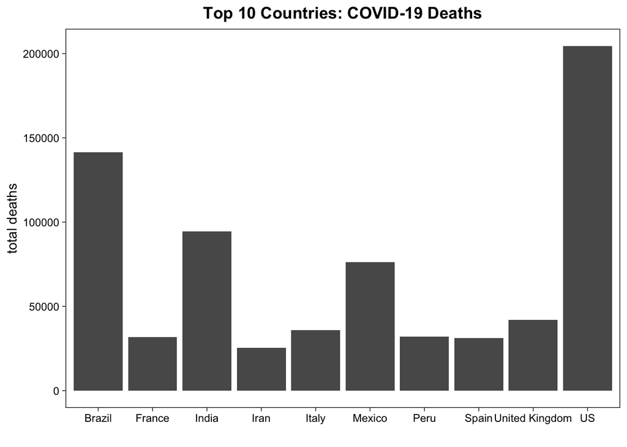

```r
library(ggplot2)

ggplot(time_series_top_deaths, aes(x=Country_Region, y=total_deaths)) +
  geom_bar(stat="identity") +
  labs(x="", y="total deaths", title="Top 10 Countries: COVID-19 Deaths") +
  theme_linedraw() +
  theme(plot.title = element_text(hjust = 0.5, face="bold"),
        panel.grid.major=element_blank(),
        panel.grid.minor=element_blank())
```

### Challenge Exercise 7

Using Facet_Wraps make a graph from the times series data with the 10 countries with the hightest death total. Format the table to look nice in the report by changing the number of rows in your graph and/or adjusting the height in the R code chunk header.

```r
library(tidyverse)

time_series_deaths <- read_csv(url("https://raw.githubusercontent.com/CSSEGISandData/COVID-19/master/csse_covid_19_data/csse_covid_19_time_series/time_series_covid19_deaths_global.csv")) %>%
  rename(Province_State = "Province/State", Country_Region = "Country/Region") %>%
  gather(key="date", value="count", 5:length(.)) %>%
  mutate(date = lubridate::mdy(date)) %>%
  filter(Country_Region %in% c("Brazil", "France", "India", "Iran", "Italy", "Mexico", "Peru", "Spain", "United Kingdom", "US")) %>%
  group_by(date, Country_Region) %>%
  summarize(total_deaths = sum(count))

head(time_series_deaths)
```

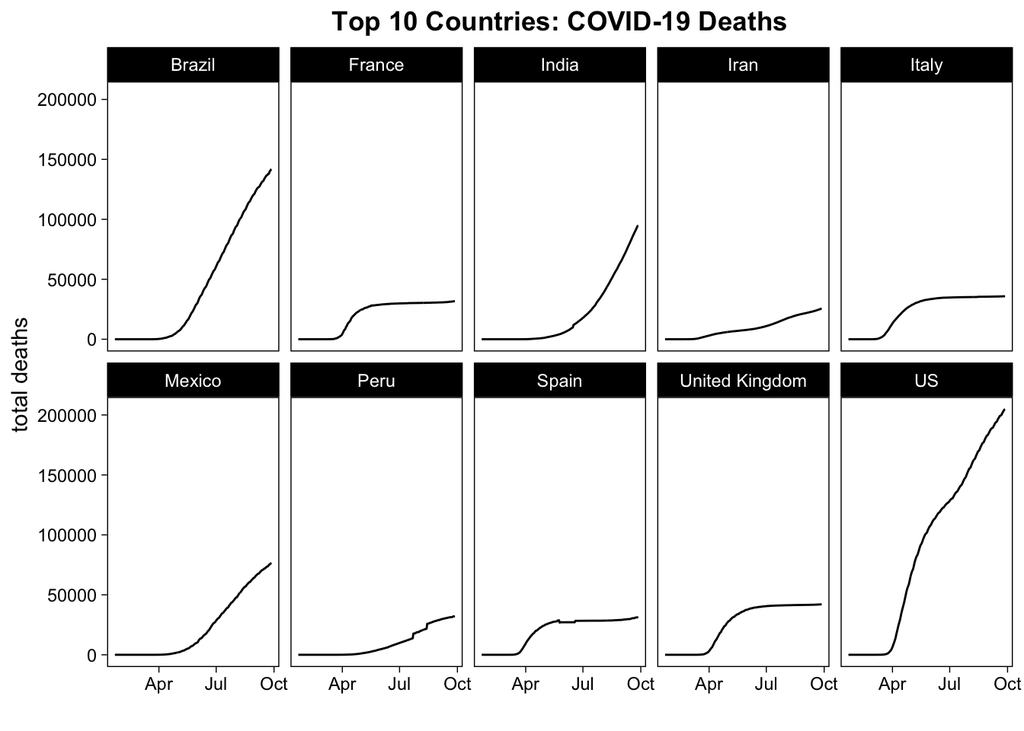

```r
library(ggplot2)

ggplot(time_series_deaths, aes(x=date, y=total_deaths)) +
  geom_line() +
  labs(x="", y="total deaths", title="Top 10 Countries: COVID-19 Deaths") +
  facet_wrap(~Country_Region, ncol=5) +
  theme_linedraw() +
  theme(plot.title = element_text(hjust=0.5, face="bold"),
        panel.grid.major = element_blank(),
        panel.grid.minor = element_blank())
```

### Challenge Exercise 8

Using Facet_Wraps make a graph from the times series data for confirmed cases for all US states and territories. (Hint: Instead of the global time series use the US time series data in the same folder time_series_covid19_deaths_US.csv and time_series_covid19_confirmed_US) Format the table to look nice in the report by changing the number of rows in your graph and/or adjusting the height in the R code chunk header.

```r
library(tidyverse)

time_series_confirmed <- read_csv(url("https://raw.githubusercontent.com/CSSEGISandData/COVID-19/master/csse_covid_19_data/csse_covid_19_time_series/time_series_covid19_confirmed_US.csv")) %>%
  select(7:length(.)) %>%
  gather(key="date", value="cases", 6:length(.)) %>%
  mutate(date = lubridate::mdy(date)) %>%
  group_by(date, Province_State) %>%
  summarize(total_cases = sum(cases))

head(time_series_confirmed)
```

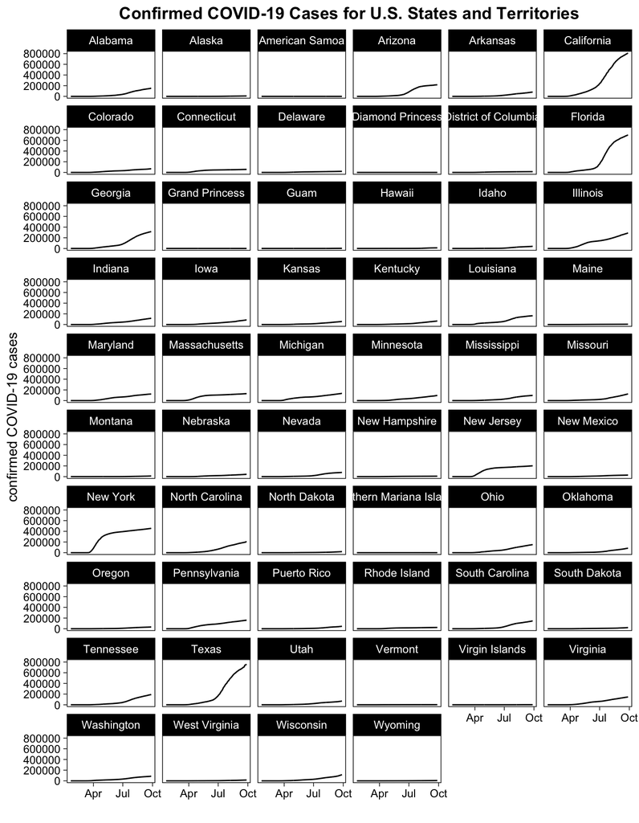

```r
options(scipen=5)

library(ggplot2)

ggplot(time_series_confirmed, aes(x=date, y=total_cases)) +
  geom_line() +
  labs(x="", y="confirmed COVID-19 cases", title="Confirmed COVID-19 Cases for U.S. States and Territories") +
  facet_wrap(~Province_State, ncol=6) +
  theme_linedraw() +
  theme(plot.title=element_text(hjust=0.5, face="bold"),
        panel.grid.major=element_blank(),
        panel.grid.minor=element_blank())
```

### Challenge Exercise 9

Apply a theme other than the one used in the Data Carpentries tutorial to the graph in Ex8.

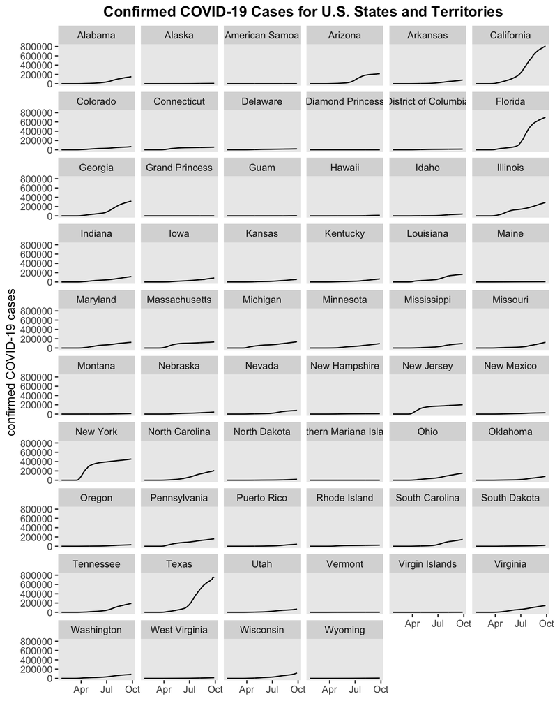

```r
options(scipen=5)

library(ggplot2)

ggplot(time_series_confirmed, aes(x=date, y=total_cases)) +
  geom_line() +
  labs(x="", y="confirmed COVID-19 cases", title="Confirmed COVID-19 Cases for U.S. States and Territories") +
  facet_wrap(~Province_State, ncol=6) +
  theme_grey() +
  theme(plot.title=element_text(hjust=0.5, face="bold"),
        panel.grid.major=element_blank(),
        panel.grid.minor=element_blank())
```